# cours_2

Cours 2

Le cours du jour traite des points suivants:

- Fonctionnement des listes en Python
- Pourquoi parle t'on de liste au lieu de tableau
- Comment fonctionnent append et insert ?
- Quelle est leur efficacité respective ?

On va parler de technique...

## Rappels liste

Une **liste** est une structure de données qui contient une séquence de valeurs.

Syntaxe:

```
[<valeur_1>, <valeur_2>, ..., <valeur_n>]
```

- Les valeurs ne sont pas nécessairement de même type.
- Une liste est une séquence

**Extrait de la documentation**

- **list.append(x)** - *Add an item to the end of the list. Equivalent to a[len(a):] = [x].*
- **list.extend(iterable)** - *Extend the list by appending all the items from the iterable. Equivalent to a[len(a):] = iterable.*
- **list.insert(i, x)** - *Insert an item at a given position. The first argument is the index of the element before which to insert, so a.insert(0, x) inserts at the front of the list, and a.insert(len(a), x) is equivalent to a.append(x).*
- **list.remove(x)** - *Remove the first item from the list whose value is equal to x. It raises a ValueError if there is no such item.*
- **list.pop([i])** - *Remove the item at the given position in the list, and return it. If no index is specified, a.pop() removes and returns the last item in the list.*

## Généralités sur la mémoire

- La mémoire peut être vue comme un long ruban avec des zones protégées
- Chaque case mémoire (un octet) dispose d'une adresse propre.
- Le stockage d'une valeur peut prendre plusieurs octets (Ex.: mot de 8 octets)
- Certaines valeurs peuvent être de type "adresse" (8 octets ?).  
  On les représente symboliquement par une flèche.

### Tableau en mémoire (vers. classique)

- Usuellement un ensemble de cases **contigues** en mémoire de **même taille**.
- On fait de l'arithmétique avec la taille d'un objet pour trouver la position d'un élément: $$@T[i] = @T[0] + i * taille(element)$$
- Avantage: Accès direct (rapide) à un élément.
- Inconvénient: Pas idéal pour des mises à jour:
  - Ajout: décalage si pas à la fin
  - Insertion/ suppression: décalage/suppression.

### Liste simplement (ou doublement) chainée (vers. classique)

- Usuellement un ensemble de cases **non contigues** en mémoire.
- Chaque élément connait son successeur (et prédecesseur si doublement chainée).
- Dispersion des éléments en mémoire.
- Une valeur spéciale indique la fin (et le début) de liste.
- Avantage: idéal pour des mises à jour (ajout, insertion, suppression)
- Inconvénient: Accès séquentiel à un élément (très lent si longue liste)

**Tableau ou Liste**:

- On doit faire un compromis entre efficacité de l'accès et des mises à jour.
- Dépend des langages de programmation (Python vs C)

## Listes (= Tableaux) en Python

### Tests préliminaires

```python
from tqdm.notebook import tqdm_notebook
import random
from time import time
n = int(10**5.5)
```

**Sondage**:

Après n appels à *append* ou *insert*, que prévoyez vous ?

- Append est plus rapide
- Insert est plus rapide
- Tous les deux prennent le même temps

```python
L = []
tps_append = []
for _ in tqdm_notebook(range(n)):
    val = random.randint(0, 100)          # nombre aléatoire
    debut = time()
    L.append(val)                         # append
    fin = time()
    tps_append.append(fin - debut)
```

```python
L = []
tps_insert = []
for _ in tqdm_notebook(range(n)):
    pos = random.randint(0, len(L))       # position aléatoire
    val = random.randint(0, 100)          # nombre aléatoire
    debut = time()
    L.insert(pos, val)                   # insert
    fin = time()
    tps_insert.append(fin - debut)
```

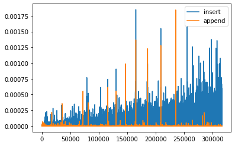

```python
import matplotlib.pyplot as plt
x = list(range(n))

plt.plot(x, tps_insert, label = "insert")
plt.plot(x, tps_append, label = "append")
plt.legend()
plt.show()
```

Conclusions partielles:

- **append** bien plus rapide qu'**insert**
- **append**: le temps semble indépendent de la taille de la liste
- **insert**: le temps croît la taille de la liste

### Liste et mémoire en Python

Une liste étant un objet, même une liste vide doit occupé de la place:

```python
from sys import getsizeof as sof    ## Nombre d'octets en mémoire
print(f"Entier: {sof(0)}")
print(f"Liste vide: {sof([])}")
```

```
Entier: 24
Liste vide: 56
```

Ne pas oublier que ce sont des objets avec des méthodes ...

```python
#dir([])
```

```python
# 8 octets par valeur de plus
sof([]), sof([1]), sof([1, 2]), sof([1, 2, 3])
```

```
(56, 64, 72, 80)
```

```python
# Et ce quel soit le type et ses valeurs
sof([]), sof(["lepetitchat"]), sof(["le", "petit"]), sof(["le", "petit", "chat"])
```

```
(56, 64, 72, 80)
```

```python
# Même en mélangeant les types
sof([]), sof(["lepetitchat"]), sof(["le", ["petit"]]), sof(["le", ["petit"], ["chat", False]])
```

```
(56, 64, 72, 80)
```

Python ne stocke donc pas directement les valeurs dans la liste mais des **références** vers les données:

- Liste = Tableau d'adresses vers les élements de la liste
- Le type des éléments de la liste n'est pas connue de la liste
- Cela optimise la place mémoire (intéressant pour la copie, pour **insert**)

Que faire si la taille initialement prévue est trop petite (insert ou append) ?

- Le système cherche un nouvel emplacement plus grand (peu couteux)
- Il recopie l'ancien contenu. De plus en plus couteux au fur et à mesure que le tableau croît.

La croissance de la taille d'une liste est gérée par la [règle](https://github.com/python/cpython/blob/master/Objects/listobject.c):

```
    new_allocated = newsize + newsize // 8 + 3 si newsize < 9 (+6 sinon)
    new_allocated ~ 1.125 * newsize
```

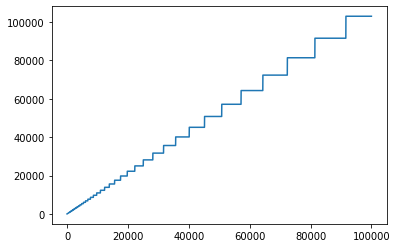

```python
import matplotlib.pyplot as plt
allocated = [0]
for size in range(1, 10**5):
    if size <= allocated[-1]:
        allocated.append(allocated[-1])
    else:
        newsize  = size + size // 8
        if size < 9:
            allocated.append(newsize+3)
        else:
            allocated.append(newsize+6)
plt.figure()
plt.plot(allocated)
plt.show()
```

Aparté: Principe identique pour les autres types

[output not shown]

```python
print(sof(0), sof(1), sof(2**30), sof(2**60), sof(2**90))
print(sof(""), sof("a"), sof("aa"), sof("aaa"), sof("aaaa"))
print(sof(tuple()), sof((1,)), sof((1,2)), sof((1,2,3)), sof((1,2,3,4)))
```

```
24 28 32 36 40
49 50 51 52 53
40 48 56 64 72
```

Que faire si la taille initialement prévue est trop grand ?

La décroissance de la taille d'une liste est gérée par la [règle](https://github.com/python/cpython/blob/master/Objects/listobject.c):

```
    si new_size < allocated //2 alors on réalloue
    sinon on garde l'allocation inchangée.
```

### Ajout en tête

Quel est la meilleure solution pour le "prepend" (ajout en tête) rapide de plusieurs élements ?

- Insertion systématique en position 0. Non !
- Append pour chaque élement puis reverse à la fin.

### Conclusion (le transparent le plus important du cours 2)

Quelles sont les méthodes lentes et rapides parmi:

L[index], insert(index, objet),

pop(), pop(index),

remove(valeur), L.append(valeur),

index(valeur)

Rapide:

- L[index]: simple calcul arithmétique
- L.append: ajout en fin + ev. réallocation (rare)
- pop(): supprime en fin + ev. réallocation (rare)

Lent:

- insert(index, objet) : décalage
- index(valeur): parcours jusqu'a trouve
- remove(valeur): parcours jusqu'a trouve + décalage (parcours entier)
- pop(index) ou del L[index]: décalage

## Compléments sur les listes

### Listes en compréhension

```
      L = [expression(x) for x in iterable if condition(x)]
```

où *iterable* est une séquence (liste, range, chaine, ...)

- La condition est optionnelle.
- Le résultat est une liste.
- En général sur une seule ligne.

Quelques usages:

- Construire une liste à partir de *range*.
- Créer une liste à partir d'une autre (filtrage)
- Se substituer à un *for* simple.
- Une liste de listes.

```python
chaine = "le petit chat"
L = [c for c in chaine]
print(L)
```

```
['l', 'e', ' ', 'p', 'e', 't', 'i', 't', ' ', 'c', 'h', 'a', 't']
```

```python
L_pairs = [x for x in range(101) if x % 2 == 0]
print(L_pairs)
L_mul3 = [x for x in L_pairs if x % 3 == 0]
print(L_mul3)
```

```
[0, 2, 4, 6, 8, 10, 12, 14, 16, 18, 20, 22, 24, 26, 28, 30, 32, 34, 36, 38, 40, 42, 44, 46, 48, 50, 52, 54, 56, 58, 60, 62, 64, 66, 68, 70, 72, 74, 76, 78, 80, 82, 84, 86, 88, 90, 92, 94, 96, 98, 100]
[0, 6, 12, 18, 24, 30, 36, 42, 48, 54, 60, 66, 72, 78, 84, 90, 96]
```

```python
L = [[x] for x in range(5)]
print(L)
L[0].append(3)
print(L)
```

```
[[0], [1], [2], [3], [4]]
[[0, 3], [1], [2], [3], [4]]
```

### Parcours simultané de plusieurs listes avec *zip*

```
     zip(*iterables)
```

où *iterables désigne 0, 1, 2, ... objets iterables (liste, chaine, dict, ...)

- le type retourné est *zip* qui est iterable ;)

```python
type(zip())
```

```
zip
```

```python
L1 = [2, 3, 5]
L2 = ['m', 'e', 't']

for (e1, e2) in zip(L1, L2):
    print(e1, '---', e2)
```

```
2 --- m
3 --- e
5 --- t
```

```python
for i, (e1, e2) in enumerate(zip(L1, L2)):
    print(i,':', e1, '---', e2)
```

```
0 : 2 --- m
1 : 3 --- e
2 : 5 --- t
```

On s'arrête sur la plus courte séquence:

```python
L1 = [2, 3, 5, 6, 1, 4]
L2 = ['m', 'e', 't']

for e1, e2 in zip(L1, L2):
    print(e1, '---', e2)
```

```
2 --- m
3 --- e
5 --- t
```

```python
for i in range(min([len(L1), len(L2), ..., len(Ln)])):
    e1 = L1[i]
    e2 = L2[i]
    ...
    en = Ln[i]
```

Autre approche possible (sans zip):

```python
L1 = [2, 3, 5, 6, 1, 4]
L2 = ['m', 'e', 't']

for i in range(min(len(L1), len(L2))):
    print(L1[i], '---', L2[i])
```

```
2 --- m
3 --- e
5 --- t
```

Cela devient difficile de faire mieux que:

```python
L1 = [2, 3, 5, 6, 1, 4]
L2 = ['m', 'e', 't', 'i', 'e', 'r']
L3 = [2**i for i in range(10)]
L4 = [True, True, False]*4

for e1, e2, e3, e4 in zip(L1, L2, L3, L4):
    print(e1, e2, e3, e4, sep=' --- ')
```

```
2 --- m --- 1 --- True
3 --- e --- 2 --- True
5 --- t --- 4 --- False
6 --- i --- 8 --- True
1 --- e --- 16 --- True
4 --- r --- 32 --- False
```